# Sentiment Analysis on Twitter Data

In this article, I'll go through the steps of carrying out sentiment analysis. Sentiment analysis is a natural language processing (NLP) method that can be used to make assessments about the positive, negative, or neutral values of data. Sentiment analysis is often performed on textual data like customer reviews and tweets for example to help businesses monitor how their customer/userbase feels about their product and thus make adjustments to their products, brand as needed. I'll show the process of tokenizing data, getting collection frequency plots, preparing the data for modeling, visualizing the dataset with wordclouds, and using VADER for polarity classification.

## Rough Outline for Sentiment Analysis using NLP

1. Installing NLTK and Downloading the Data
2. Tokenizing the Data
3. Normalizing the Data
4. Removing Noise from the Data
   - Converting Tokens to a Dictionary
   - Splitting the Dataset for Training and Testing the Model
5. Determining Word Density
6. Preparing Data for the Model
   - Contructing dictionary
   - Splitting data into training and testing sets
7. Building and Testing the Model
8. Put tweets into dataframe (this could be done earlier)
9. Get polarity scores via VADER
10. Data visualizations (Word Clouds, frequency plots, ...)

## Modules used in this work

The following modules are used in sentiment analysis applications.

- nltk : Used for natural language processing.
- re : Used for regular expression operations.
- string : Used for common string operations

The API documentation for each of these modules can be found here:

- https://www.nltk.org/api/nltk.html
- https://docs.python.org/3/library/re.html
- https://docs.python.org/3/library/string.html

```python
#Stuff for general sentiment analysis
import nltk
from nltk.corpus import twitter_samples,stopwords
from nltk.tag import pos_tag
from nltk.stem.wordnet import WordNetLemmatizer
from nltk.tokenize import word_tokenize
from nltk import FreqDist, classify, NaiveBayesClassifier

#Stuff for VADER
nltk.download('vader_lexicon')
from nltk.sentiment.vader import SentimentIntensityAnalyzer

#Stuff for dealing with strings and regular expressions
import re, string, random
```

## Step 1: Downloading data from NLTK

This section will delineate the basic steps of loading and preliminary inspection of our data using NLTK.

## Loading data with NLTK

The first thing that needs to be done is load the data onto our jupyter notebook. NLTK has a download method from which we can extract a variety of data from a variety of sources. You can find the complete list of datasets available to NLTK here: https://www.nltk.org/nltk_data/

Here I'll be downloading the datasets shown below

```python
#Downloading the data
nltk.download('twitter_samples') #30000 tweets. 5000 positive, 5000 negative. Rest are neutral.
nltk.download('punkt') #Pretrained model to tokenize words
nltk.download('wordnet') #Lexical database to help determine base word
nltk.download('averaged_perceptron_tagger') #Used to determine context of word in sentence
nltk.download('omw-1.4')
nltk.download('stopwords')
```

```
True
```

## Step 2 — Tokenizing the Data

Now that we have downloaded the data we want, we have to tokenize it.

The process of tokenizing splits strings into smaller parts called tokens. Think of a token as the smallest unit of text that can be parsed by the computer (analogues to phonemes and morphemes). This is done because computers don't know how to accurately process language in its original form.

Tokens can be any sequence of words, emojis, hashtags, links, or an individual character.

One of the datasets that was download was the "twitter_samples" dataset which is made up of 30,000 tweets. 5000 tweets have negative sentiments associated with them, 5000 tweets have positive sentiments associated with them, and 20000 tweets have no sentiments associated with them. The data associated with each of these 3 sentiments (positive, negative, neutral) will be stored in the variables below:

```python
positive_tweets = twitter_samples.strings('positive_tweets.json')
negative_tweets = twitter_samples.strings('negative_tweets.json')
text = twitter_samples.strings('tweets.20150430-223406.json')
```

Before tokenizing the data, we need a pre-trained model that will our subsequent tokenizing efforts. In this example, the pre-trained model will be the "punkt" resource which was downloaded earlier. Now we can tokenize the data using the tokenized method which produces the array below

```python
tweet_tokens = twitter_samples.tokenized('positive_tweets.json')
print(tweet_tokens[:5])
```

```
[['#FollowFriday', '@France_Inte', '@PKuchly57', '@Milipol_Paris', 'for', 'being', 'top', 'engaged', 'members', 'in', 'my', 'community', 'this', 'week', ':)'], ['@Lamb2ja', 'Hey', 'James', '!', 'How', 'odd', ':/', 'Please', 'call', 'our', 'Contact', 'Centre', 'on', '02392441234', 'and', 'we', 'will'…
```

This tokenization returns the content of a bunch of tweets from that dataset as an array. As can be seen, the array is composed of a bunch of words and emojis. In addition to this, many of these entries also have unwanted characters within them (i.e., @ and _ ). These characters will need to be removed as part of the data cleanup.

## Step 3 — Normalizing the Data

Words can be expressed in a variety of ways to convey meaning. For instance, ate and eaten are different tenses of the verb eat. An analysis may require these different tenses to be converted into their base, fundamental, canonical form. This process is known as normalization.

**Normalization** is helpful because it allows us to group words together that have the same overarching meaning but have different written forms. You can think of the normalization process of a sort of clustering method but applied to words. Two methods that are commonly employed for this are stemming and lemmatization. The differences between the two are shown in the image below:

[figure not shown]

In **stemming** we are removing affixes. An **affix** is a morpheme that is added to a word to change its meaning. Common affixes are prefixes (an affix that is added to the beginning of a word) and suffixes (an affix that is added at the end of a word). Stemming is useful when dealing with simple verb forms and is thus a bit of a crude heuristic process.

In **lemmatization**, the algorithm normalizes a word within the context of vocabulary and through the use of morphological analysis in order to produce a lemma. A lemma in morphology is known as the canonical or dictionary form of a set of word forms. This lemmatization process allows different words to be indexed,mapped, or traced back to a single word. For instance, speak, speaks, spoke, spoken and speaking are all forms of speak (known as the lexeme).

As is the case with algorithms, one must always consider the tradeoffs between speed and accuracy. Stemming is generally faster than lemmatization but is also less accurate. Lemmatization is slower but generates more accurate results. I'll be using lemmatization in this demo.

Now that normalization schemes have been established let's determine the context of each word in the text. This process will give a tag (tagging algorithm) to each word that allows words to be related to one another. This is done via the `pos_tag` function in nltk.

```python
tweet_tokens = twitter_samples.tokenized('positive_tweets.json')
print(pos_tag(tweet_tokens[0]))
```

```
[('#FollowFriday', 'JJ'), ('@France_Inte', 'NNP'), ('@PKuchly57', 'NNP'), ('@Milipol_Paris', 'NNP'), ('for', 'IN'), ('being', 'VBG'), ('top', 'JJ'), ('engaged', 'VBN'), ('members', 'NNS'), ('in', 'IN'), ('my', 'PRP$'), ('community', 'NN'), ('this', 'DT'), ('week', 'NN'), (':)', 'NN')]
```

The output of this function is an array of tuples. Each array element is composed of a word in our tweet list and a tag value (i.e. JJ, NNP, etc.). You can find the meaning of each of these tags here: https://www.ling.upenn.edu/courses/Fall_2003/ling001/penn_treebank_pos.html.

Some of the tags found in the twitter sample are listed below with their corresponding meaning:

- NNP: Noun, proper, singular
- NN: Noun, common, singular or mass
- IN: Preposition or conjunction, subordinating
- VBG: Verb, gerund or present participle
- VBN: Verb, past participle

Therefore, through these tags we can determine whether a word is a noun or a verb and so on and so forth. The function below will lemmatize a sentence and assigns each word as either a verb or a noun. The function below can be readily modified to incorporate things like adjectives, pronouns ,symbols and other things.

```python
def lemmatize_sentence(tokens):
    lemmatizer = WordNetLemmatizer()
    lemmatized_sentence = []
    for word, tag in pos_tag(tokens):
        if tag.startswith('NN'):
            pos = 'n'
        elif tag.startswith('VB'):
            pos = 'v'
        else:
            pos = 'a'
        lemmatized_sentence.append(lemmatizer.lemmatize(word, pos))
    return lemmatized_sentence

print(lemmatize_sentence(tweet_tokens[0]))
```

```
['#FollowFriday', '@France_Inte', '@PKuchly57', '@Milipol_Paris', 'for', 'be', 'top', 'engage', 'member', 'in', 'my', 'community', 'this', 'week', ':)']
```

From the output, we can see that some of the words on the original tweet changed after applying the lemmatizer. For example, the word `being` changed to `be` amd the word `members` was changed to `member`. Now that we have a way to normalize our data, we can start removing noise from the data.

## Step 4- Removing Noise from Text Data

Noise in any kind of data can be defined as any unwanted signal. When dealing with text data for sentiment analysis, noise will depend on what features of the data do not add meaning or information to our dataset and must be chosen carefully.

A word that can be typically considered as text noise is known as a `stop word`. Stop words are the most common words in a language and are generally filtered out from language processing. Some examples of common stop words in English are words like "the", "is", "for","was" and "a". You can also define the stop words for your particular dataset by building a `stop list` based on the `collection frequency` of the words. Collection frequency refers to the total number of times a term appears in a document. The words with highest collection frequency are generally the stop words.

In addition to removing stop words from our dataset, other sources of noise that will be removed from our Twitter data are:

- Hyperlinks
- Twitter Username handles
- Punctuation
- Special Characters

To remove hyperlinks, we'll use regular expressions that will replace any strings that begin with `http://` or `https://` with an empty string using the `.sub` method.

`re.sub('http[s]?://(?:[a-zA-Z]|[0-9]|[$-_@.&+#]|[!*\(\),]|(?:%[0-9a-fA-F][0-9a-fA-F]))+','', token)`

To remove twitter handles we'll remove stuff that begins with @

`re.sub("(@[A-Za-z0-9_]+)","", token)`

To remove punctuation we can use the `string.punctuation` method.

To remove stop words we can use the stop words dictionary built into nltk

`stop_words = stopwords.words('english')`

Putting it all together, allows us to define the denoising function below:

```python
stop_words = stopwords.words('english')

def remove_noise(tweet_tokens, stop_words = ()):

    cleaned_tokens = []

    for token, tag in pos_tag(tweet_tokens):
        token = re.sub('http[s]?://(?:[a-zA-Z]|[0-9]|[$-_@.&+#]|[!*\(\),]|'\
                       '(?:%[0-9a-fA-F][0-9a-fA-F]))+','', token)
        token = re.sub("(@[A-Za-z0-9_]+)","", token)

        if tag.startswith("NN"):
            pos = 'n'
        elif tag.startswith('VB'):
            pos = 'v'
        else:
            pos = 'a'

        lemmatizer = WordNetLemmatizer()
        token = lemmatizer.lemmatize(token, pos)

        if len(token) > 0 and token not in string.punctuation and token.lower() not in stop_words:
            cleaned_tokens.append(token.lower())
    return cleaned_tokens
```

Let's see what happens after running our denoising function

```python
print(remove_noise(tweet_tokens[0], stop_words))
```

```
['#followfriday', 'top', 'engage', 'member', 'community', 'week', ':)']
```

Cool! We've succesfully removed twitter handles from our data. Stop words have also been removed. Notice how the words have also all been turned to lowercase.

Let's apply our denoising function to all the tweets in our data now using the code below.

```python
#Clean up of all tweets
positive_tweet_tokens = twitter_samples.tokenized('positive_tweets.json')
negative_tweet_tokens = twitter_samples.tokenized('negative_tweets.json')

positive_cleaned_tokens_list = []
negative_cleaned_tokens_list = []

for tokens in positive_tweet_tokens:
    positive_cleaned_tokens_list.append(remove_noise(tokens, stop_words))

for tokens in negative_tweet_tokens:
    negative_cleaned_tokens_list.append(remove_noise(tokens, stop_words))
```

As a sanity check let's look at the original tweet and then the denoised tweet:

```python
print('This is the tweet that\'s being denoised')
print(positive_tweet_tokens[300])
```

```
This is the tweet that's being denoised
['Stats', 'for', 'the', 'day', 'have', 'arrived', '.', '2', 'new', 'followers', 'and', 'NO', 'unfollowers', ':)', 'via', 'http://t.co/xxlXs6xYwe', '.']
```

```python
print('This is the denoised tweet:')
print(positive_cleaned_tokens_list[300])
```

```
This is the denoised tweet:
['stats', 'day', 'arrive', '2', 'new', 'follower', 'unfollowers', ':)', 'via']
```

Something to keep in mind here, is that words that haven't been spaced out are treated as a single word. For example, the phrase 'IamVeryHappy' would be treated as a single word instead of four different words and will require a specific script to handle these kinds of cases.

## Step 5 - Determining Word Density

Let's find out what the most common words are on our denoised tweet database by building a collection frequency generator function and pair it with the `.most_common` method from nltk. I've also plotted the distribution for each of the positive and negative tokens below.

```python
def get_all_words(cleaned_tokens_list):
    for tokens in cleaned_tokens_list:
        for token in tokens:
            yield token
```

```
These are the 20 most common words in the positive tweets:
[(':)', 3691), (':-)', 701), (':d', 658), ('thanks', 388), ('follow', 357), ('love', 333), ('...', 290), ('good', 283), ('get', 263), ('thank', 253), ('u', 245), ('day', 242), ('like', 229), ('see', 195), ('happy', 192), ("i'm", 183), ('great', 175), ('hi', 173), ('go', 167), ('back', 163)]
```

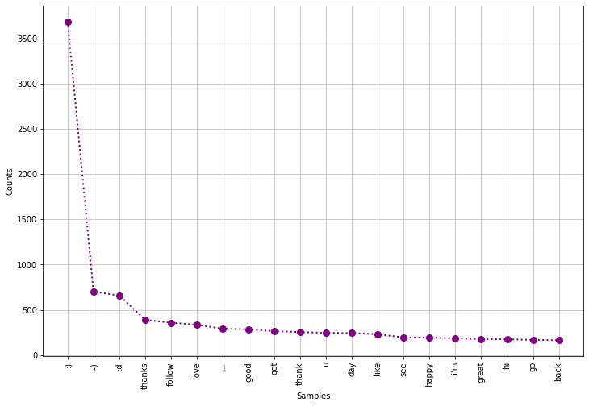

```python
all_pos_words = get_all_words(positive_cleaned_tokens_list)
freq_dist_pos = FreqDist(all_pos_words)
print('These are the 20 most common words in the positive tweets:')
print(freq_dist_pos.most_common(20))
fig = plt.figure(figsize=(12,8))
freq_dist_pos.plot(20, cumulative=False,color = 'purple', linestyle = ':', marker='.', markersize=16)
plt.show()
```

```
These are the 20 most common words in the negative tweets:
[(':(', 4585), (':-(', 501), ("i'm", 343), ('...', 332), ('get', 325), ('miss', 291), ('go', 275), ('please', 275), ('want', 246), ('like', 218), ('♛', 210), ('》', 210), ('u', 193), ("can't", 180), ('time', 160), ('follow', 156), ('sorry', 149), ('one', 149), ('see', 145), ('day', 144)]
```

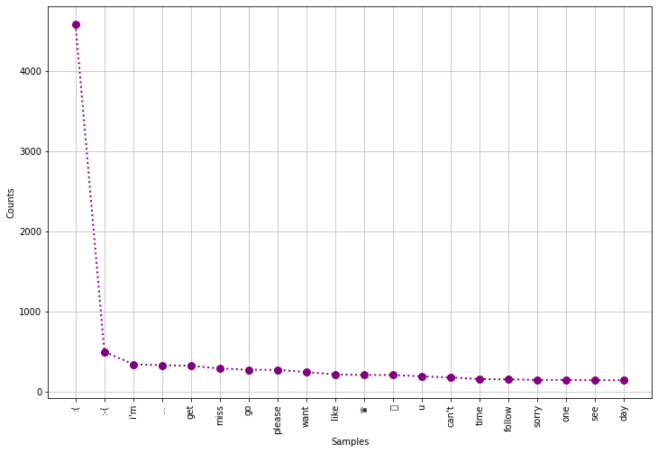

```python
all_neg_words = get_all_words(negative_cleaned_tokens_list)
freq_dist_neg = FreqDist(all_neg_words)
print('These are the 20 most common words in the negative tweets:')
print(freq_dist_neg.most_common(20))
fig = plt.figure(figsize=(12,8))
freq_dist_neg.plot(20, cumulative=False,color = 'purple', linestyle = ':', marker='.', markersize=16)
plt.show()
```

Look at that! The :) and :( emoji's are parsed as positive and negative respectively and are also the most common elements in their respective lists. Now let's start building the model.